# Project 1

Natalia Sifnugel

2023-09-16

```r
library(tidyverse)
library(tidytuesdayR)
library(here)
library(gapminder)
library("magrittr")
library("paletteer")
library(ggthemes)
library(bbplot)
library(sessioninfo)

if (!dir.exists(here("data"))) {
  dir.create(here("data"))
}

if (!file.exists(here("data", "chocolate.RDS"))) {
  url_csv <- "https://raw.githubusercontent.com/rfordatascience/tidytuesday/master/data/2022/2022-01-18/chocolate.csv"
  chocolate <- read_csv(url_csv)
  saveRDS(chocolate, file = here("data", "chocolate.RDS"))
}

chocolate <- readRDS(here("data", "chocolate.RDS"))
as_tibble(chocolate)
```

```
## # A tibble: 2,530 × 10
##      ref company_manufacturer company_location review_date
##    <dbl> <chr>                <chr>                  <dbl>
##  1  2454 5150                 U.S.A.                  2019
##  2  2458 5150                 U.S.A.                  2019
##  3  2454 5150                 U.S.A.                  2019
##  4  2542 5150                 U.S.A.                  2021
##  5  2546 5150                 U.S.A.                  2021
##  6  2546 5150                 U.S.A.                  2021
##  7  2542 5150                 U.S.A.                  2021
##  8   797 A. Morin             France                  2012
##  9   797 A. Morin             France                  2012
## 10  1011 A. Morin             France                  2013
## # ℹ 2,520 more rows
## # ℹ 6 more variables: country_of_bean_origin <chr>,
## #   specific_bean_origin_or_bar_name <chr>, cocoa_percent <chr>,
## #   ingredients <chr>, most_memorable_characteristics <chr>, rating <dbl>
```

```r
glimpse(chocolate)
```

```
## Rows: 2,530
## Columns: 10
## $ ref                              <dbl> 2454, 2458, 2454, 2542, 2546, 2546, 2…
## $ company_manufacturer             <chr> "5150", "5150", "5150", "5150", "5150…
## $ company_location                 <chr> "U.S.A.", "U.S.A.", "U.S.A.", "U.S.A.…
## $ review_date                      <dbl> 2019, 2019, 2019, 2021, 2021, 2021, 2…
## $ country_of_bean_origin           <chr> "Tanzania", "Dominican Republic", "Ma…
## $ specific_bean_origin_or_bar_name <chr> "Kokoa Kamili, batch 1", "Zorzal, bat…
## $ cocoa_percent                    <chr> "76%", "76%", "76%", "68%", "72%", "8…
## $ ingredients                      <chr> "3- B,S,C", "3- B,S,C", "3- B,S,C", "…
## $ most_memorable_characteristics   <chr> "rich cocoa, fatty, bready", "cocoa, …
## $ rating                           <dbl> 3.25, 3.50, 3.75, 3.00, 3.00, 3.25, 3…
```

# Part 1: Explore data

#### 1. Histogram of ratings

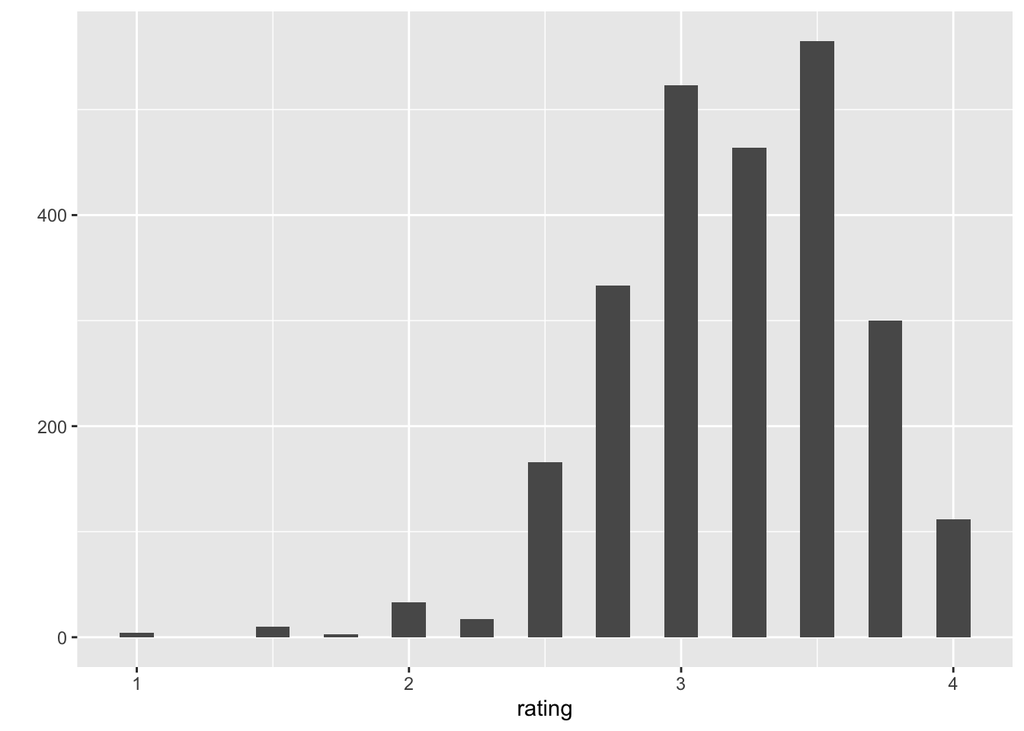

```r
qplot(rating, data = chocolate, bins = 25)
```

Adjusting the bin size impacts how the data are grouped. Increasing the bin size aggregated the data in smaller groups. Since fewer data points contribute to each group/bin, each individual point is better represented, resulting in a more detailed histogram. I chose the bins=25 because I think it looks the best visually. The bars in the histogram are evenly spread and the central tendency of the distribution is clear.

#### 2. Reviews per country

```r
chocolate %>%
  group_by(country_of_bean_origin) %>%
  summarize(tibble(
    `number_of_ratings` = length(rating))) %>%
    unique() %>%
    arrange(desc(number_of_ratings)) %>%
  print(n=Inf)
```

```
## # A tibble: 62 × 2
##    country_of_bean_origin number_of_ratings
##    <chr>                              <int>
##  1 Venezuela                            253
##  2 Peru                                 244
##  3 Dominican Republic                   226
##  4 Ecuador                              219
##  5 Madagascar                           177
##  6 Blend                                156
##  7 Nicaragua                            100
##  8 Bolivia                               80
##  9 Colombia                              79
## 10 Tanzania                              79
## 11 Brazil                                78
## 12 Belize                                76
```

[output cut: 50 more lines]

#### 3. Ecuador summary

```r
summary_ecuador <- chocolate %>%
  filter(country_of_bean_origin == "Ecuador") %>%
  summarize(tibble(
    `mean` = mean(rating),
    `sd` = sd(rating),
    `total` = length(rating)
  ))

print(summary_ecuador)
```

```
## # A tibble: 1 × 3
##    mean    sd total
##   <dbl> <dbl> <int>
## 1  3.16 0.512   219
```

#### 4. Company making the best chocolate with Ecuadorian beans

```r
chocolate %>%
  filter(country_of_bean_origin == "Ecuador") %>%
  group_by(company_manufacturer) %>%
  summarize(
    average_rating = mean(rating)
  ) %>%
  arrange(desc(average_rating))
```

```
## # A tibble: 136 × 2
##    company_manufacturer   average_rating
##    <chr>                           <dbl>
##  1 Amano                            4
##  2 Benoit Nihant                    4
##  3 Beschle (Felchlin)               4
##  4 Durci                            4
##  5 Smooth Chocolator, The           4
##  6 Domori                           3.88
##  7 A. Morin                         3.75
##  8 Cacao Sampaka                    3.75
##  9 Foundry                          3.75
## 10 Goodnow Farms                    3.75
## # ℹ 126 more rows
```

Based on the average rating, five companies are tied for the highest rated chocolate using Ecuadorian beans. These companies are Amano, Benoit Nihant, Beschle (Felchlin), Durci, and Smooth Chocolator.

#### 5. Countries with highest rated beans

```r
chocolate %>%
  group_by(country_of_bean_origin) %>%
  summarize(
    average_rating = mean(rating)) %>%
  arrange(desc(average_rating))
```

```
## # A tibble: 62 × 2
##    country_of_bean_origin average_rating
##    <chr>                           <dbl>
##  1 Tobago                           3.62
##  2 China                            3.5
##  3 Sao Tome & Principe              3.5
##  4 Solomon Islands                  3.45
##  5 Congo                            3.32
##  6 Thailand                         3.3
##  7 Cuba                             3.29
##  8 Vietnam                          3.29
##  9 Papua New Guinea                 3.28
## 10 Madagascar                       3.27
## # ℹ 52 more rows
```

The three countries with the highest rated beans are Tobago, China, and Sao Tome & Principe.

#### 6. Countries with highest rated beans if the number of reviews is greater than 10

```r
chocolate %>%
  group_by(country_of_bean_origin) %>%
  mutate(number_of_ratings = length(rating)) %>%
  filter(number_of_ratings >= 10) %>%
  summarize(
    average_rating = mean(rating)) %>%
  arrange(desc(average_rating))
```

```
## # A tibble: 35 × 2
##    country_of_bean_origin average_rating
##    <chr>                           <dbl>
##  1 Solomon Islands                  3.45
##  2 Congo                            3.32
##  3 Cuba                             3.29
##  4 Vietnam                          3.29
##  5 Papua New Guinea                 3.28
##  6 Madagascar                       3.27
##  7 Haiti                            3.27
##  8 Brazil                           3.26
##  9 Guatemala                        3.26
## 10 Nicaragua                        3.26
## # ℹ 25 more rows
```

Removing countries who received less than 10 reviews changes the top three highest rated countries. The top three highest rated countries of bean origin based on this stratification are Solomon Islands, Congo, and Cuba.

#### 7. Relationship between percent chocolate and ratings

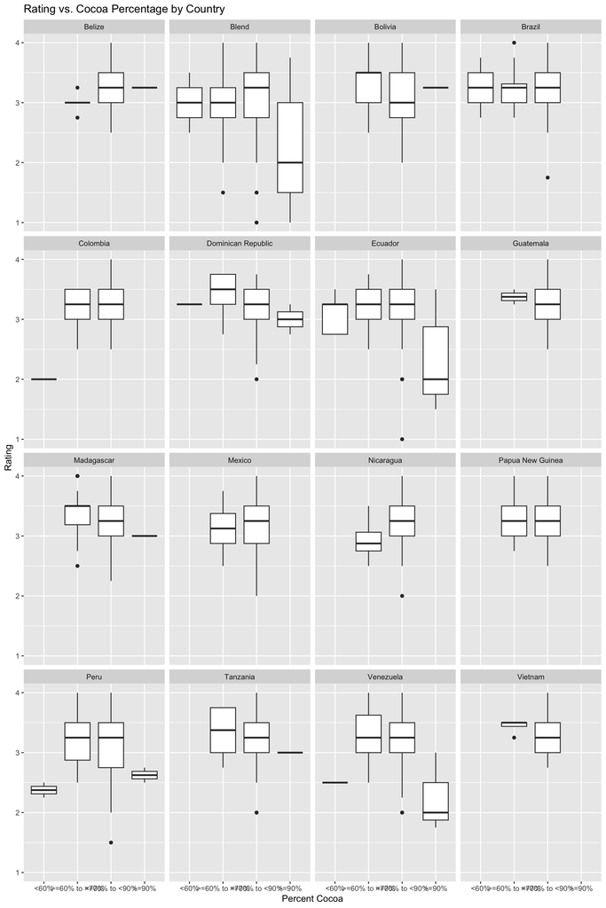

```r
chocolate_reviews_50 <- chocolate %>%
  group_by(country_of_bean_origin) %>%
  mutate(number_of_ratings = length(rating)) %>%
  filter(number_of_ratings >= 50) %>%
  mutate(cocoa_percent_integer = as.integer(substr(cocoa_percent,1,1))) %>%
  mutate(cocoa_percent_group = case_when(
    cocoa_percent_integer > 2 & cocoa_percent_integer < 6 ~ "<60%",
    cocoa_percent_integer == 6 ~ ">=60% to <70%",
    cocoa_percent_integer == 7 | cocoa_percent_integer == 8 ~ ">=70% to <90%",
    cocoa_percent_integer == 1 | cocoa_percent_integer == 9 ~ ">=90%"
  )) %>%
  arrange(cocoa_percent_group)

ggplot(data = chocolate_reviews_50) +
  geom_boxplot(aes( x = cocoa_percent_group, y = rating)) +
  #facet_grid(country_of_bean_origin ~ .) +
  facet_wrap(~ country_of_bean_origin, ncol = 4) +
  labs(title = "Rating vs. Cocoa Percentage by Country",
    x = "Percent Cocoa",
    y = "Rating")
```

# Part 2: Join two datasets together

#### Adding continent to chocolate dataset

```r
gapminder_country_continent <- gapminder %>%
    rename(country_of_bean_origin = country) %>%
    select(country_of_bean_origin,continent) %>%
    unique()

chocolate <- left_join(x = chocolate, y = gapminder_country_continent, by = "country_of_bean_origin")
```

#### Creating new dataset, filtering out “Blend” country of origin and countries with less than 10 reviews

```r
chocolate_noblend_10reviews <- chocolate %>%
  group_by(country_of_bean_origin) %>%
  filter(country_of_bean_origin != "Blend") %>%
  mutate(number_of_ratings = length(rating)) %>%
  filter(number_of_ratings >= 10)
```

#### Looking for NAs in continent column and creating a complete country/continent dataset

```r
complete_continent_list <- chocolate_noblend_10reviews %>%
  select(country_of_bean_origin, continent) %>%
  filter(is.na(continent)) %>%
  unique() %>%
  select(country_of_bean_origin) %>%
  add_column(continent = c("Oceania", "Oceania", "Africa", "Oceania", "Americas", "Americas", "Americas","Africa", "Oceania","Americas","Americas" )) %>%
  rbind(gapminder_country_continent)
```

#### Updating NAs in filtered chocolate data set

```r
chocolate_noblend_10reviews <- chocolate_noblend_10reviews %>%
  select(-(continent))

chocolate_noblend_10reviews <- left_join(x = chocolate_noblend_10reviews, y = complete_continent_list, by = "country_of_bean_origin")
```

#### Violin plots comparing ratings by continent

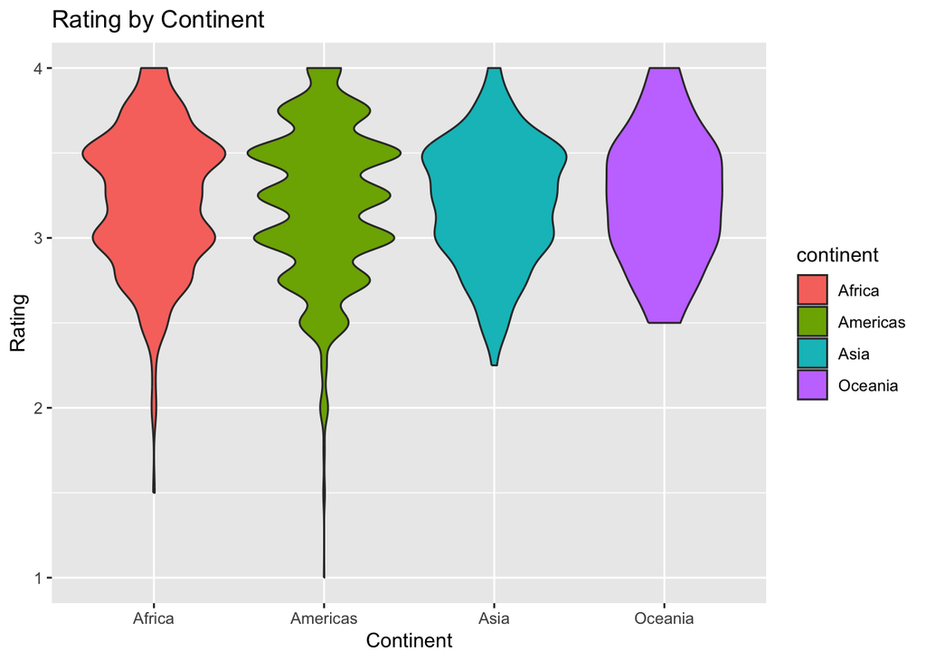

```r
ggplot(chocolate_noblend_10reviews, aes(x=continent, y=rating, fill = continent))+
  geom_violin() +
  labs(title = "Rating by Continent",
    x = "Continent",
    y = "Rating")
```

# Part 3: Convert wide data into long data

#### Creating columns for specific ingredients and memorable characteristcs, grouping by review year, and calculating column means

```r
chocolate_ingredients_flavors <- chocolate %>%
  select(ref,review_date,ingredients,most_memorable_characteristics)%>%
  mutate(beans = case_when(
    grepl("B",ingredients) == TRUE ~ 1,
    grepl("B",ingredients) == FALSE ~ 0
  )) %>%
  mutate(sugar = case_when(
    grepl("S",ingredients) == TRUE ~ 1,
    grepl("S",ingredients) == FALSE ~ 0
  )) %>%
  mutate(cocoa_butter = case_when(
    grepl("C",ingredients) == TRUE ~ 1,
    grepl("C",ingredients) == FALSE ~ 0
  ))%>%
  mutate(vanilla = case_when(
    grepl("V",ingredients) == TRUE ~ 1,
    grepl("V",ingredients) == FALSE ~ 0
  ))%>%
  mutate(lectin = case_when(
    grepl("L",ingredients) == TRUE ~ 1,
    grepl("L",ingredients) == FALSE ~ 0
  )) %>%
  mutate(salt = case_when(
    grepl("Sa",ingredients) == TRUE ~ 1,
    grepl("Sa",ingredients) == FALSE ~ 0
  )) %>%
  mutate(char_cocoa = case_when(
    grepl("cocoa",most_memorable_characteristics) == TRUE ~ 1,
    grepl("cocoa",most_memorable_characteristics) == FALSE ~ 0
  ))  %>%
  mutate(char_sweet = case_when(
    grepl("sweet",most_memorable_characteristics) == TRUE ~ 1,
    grepl("sweet",most_memorable_characteristics) == FALSE ~ 0
  ))  %>%
  mutate(char_nutty = case_when(
    grepl("nutty",most_memorable_characteristics) == TRUE ~ 1,
    grepl("nutty",most_memorable_characteristics) == FALSE ~ 0
  )) %>%
  mutate(char_creamy = case_when(
    grepl("creamy",most_memorable_characteristics) == TRUE ~ 1,
    grepl("creamy",most_memorable_characteristics) == FALSE ~ 0
  ))%>%
  mutate(char_roasty = case_when(
    grepl("roasty",most_memorable_characteristics) == TRUE ~ 1,
    grepl("roasty",most_memorable_characteristics) == FALSE ~ 0
  )) %>%
  mutate(char_earthy = case_when(
    grepl("earthy",most_memorable_characteristics) == TRUE ~ 1,
    grepl("earthy",most_memorable_characteristics) == FALSE ~ 0
  ))  %>%
    group_by(review_date) %>%
    summarize(beans = mean(beans),
              sugar = mean(sugar),
              cocoa_butter = mean(cocoa_butter),
              vanilla = mean(vanilla),
              lectin = mean(lectin),
              salt = mean(salt),
              char_cocoa = mean(char_cocoa),
              char_sweet = mean(char_sweet),
              char_nutty = mean(char_nutty),
              char_creamy = mean(char_creamy),
              char_roasty = mean(char_roasty),
              char_earthy = mean(char_earthy)
              )
```

#### Making ingredient and characteristc data tidy

```r
chocolate_ingredients_flavors_tidy <- chocolate_ingredients_flavors %>%
  pivot_longer(-review_date, names_to = "feature", values_to = "mean_score") %>%
  mutate(review_date = factor(review_date), feature = factor(feature))
print(chocolate_ingredients_flavors_tidy)
```

```
## # A tibble: 192 × 3
##    review_date feature      mean_score
##    <fct>       <fct>             <dbl>
##  1 2006        beans            0.968
##  2 2006        sugar            0.968
##  3 2006        cocoa_butter     0.903
##  4 2006        vanilla          0.694
##  5 2006        lectin           0.694
##  6 2006        salt             0
##  7 2006        char_cocoa       0.210
##  8 2006        char_sweet       0.161
##  9 2006        char_nutty       0.0323
## 10 2006        char_creamy      0.242
## # ℹ 182 more rows
```

# Part 4: Data visualization

#### Creating scatter plot of mean score chocolate ingredient and characteristic tidy data

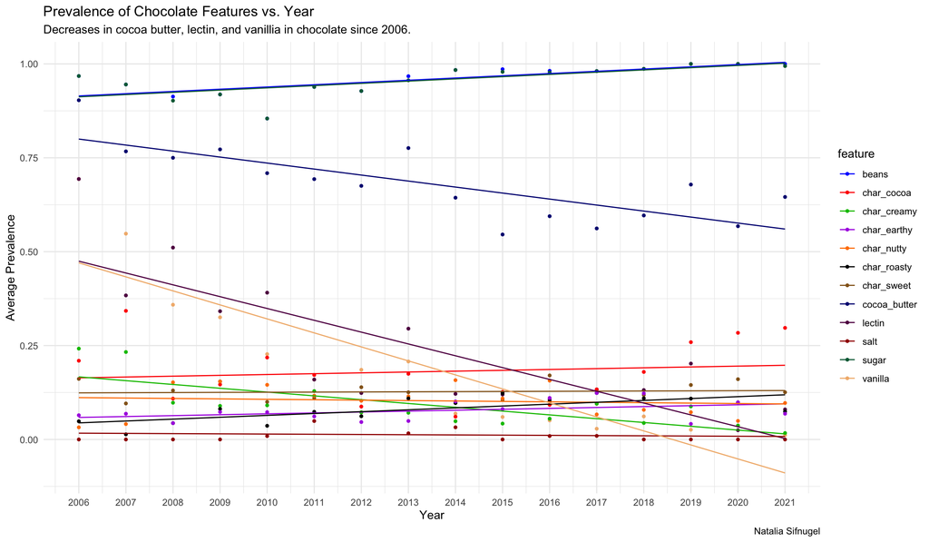

```r
chocolate_ingredients_flavors_tidy %>%
  ggplot(aes((as.numeric(review_date)+2005), mean_score,color = feature)) +
  geom_point(
    size = 1,
  ) +
  geom_smooth(
    se = FALSE,
    linewidth = 0.5,
    method = "lm"
  ) +
  labs(title = "Prevalence of Chocolate Features vs. Year",
       subtitle = "Decreases in cocoa butter, lectin, and vanillia in chocolate since 2006.",
    x = "Year",
    y = "Average Prevalence",
    caption = "Natalia Sifnugel")+
  scale_x_continuous(n.breaks=16) +
  theme_minimal() +
  scale_color_manual(values = paletteer_d("ggprism::colors", 13))
```

# Part 5: The worst plot

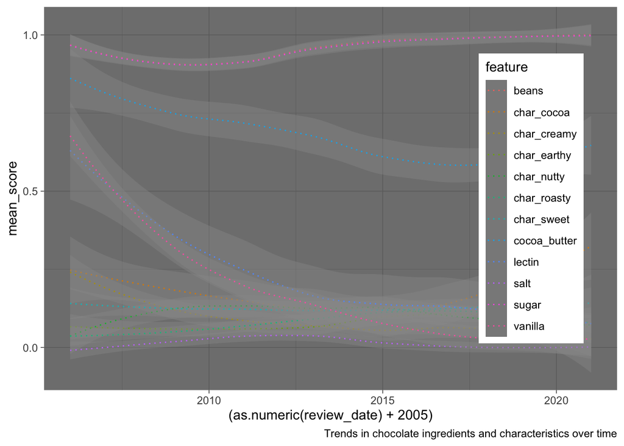

```r
chocolate_ingredients_flavors_tidy %>%
  ggplot(aes((as.numeric(review_date)+2005), mean_score,color = feature)) +
  geom_smooth(
    linetype = 3,
    se = TRUE,
    linewidth = 0.5,
    method = "loess"
  ) +
  scale_x_continuous(n.breaks=4) +
  scale_y_continuous(n.breaks=4) +
  theme_dark() +
  theme(legend.position = c(0.85, 0.5)) +
  labs(caption = "Trends in chocolate ingredients and characteristics over time")
```

#### Customizations

- **Data point color palette**: For this figure, I highlighted each feature by color, but I did not specify the color palette. The default ggplot colors are somewhat neon which obscures the data. The automatic settings also generate a gradient for the different features. Because there are so many features, the difference in color is weak, which makes it difficult to distinguish between features on the graph.
- **Use of Dark theme**: Ggplot offers many different themes. I elected to use the dark one for this part of the project because it requires data points are correctly colored to create enough contrast for strong visualization. In this graph, the data points do not have enough contrast for clear visibility.
- **Inclusion of SE**: Many of the data points are overlapping. Including the SE in this graph covers data in the overlapping regions, contributing to the poor representation.
- **Size and type of line**: I used a small line size (0.5), which I thought would be better because there are many overlapping data points. However, the size also contributes to the poor visualization created by the color palette and dark theme. I also used line type 3 which consists of points rather than a continuous line . This can be confusing for the reader because at first glance, they might consider this a dot plot.
- **Axis elements**: I did not rename the axes in this graph, making it difficult to understand what the data represent and derive any meaning. I also adjusted the breaks on the axes such that there are few tick marks which leads to more estimation when determining the values of the data points.
- **Legend Position**: I wanted practice changing the position of the legend, so I moved it into the graph. This positioning covers the data points from 2017 and on.
- **Misuse of Caption**: In the caption, I included some information about the graph, but it does not stand out, meaning viewers are likely to skip over it and struggle to understand what is being depicted.